# RPC-PI Experiment - Training Time Analysis

2026-07-04

# 1 Objective

This R Markdown analyzes **training time and training efficiency** for the trained defense scenarios.

The main questions are:

```
How long did each defense take to train?
Which training method was more expensive?
How stable was training time across seeds?
How do elapsed time, train runtime, throughput, FLOPs, and train loss vary by scenario?
```

This report focuses on:

```
C2 - StruQ-like SFT
C3 - SecAlign-like DPO
C4 - Instruction-Hierarchy-like SFT
```

C0 is the base model and C1 is format-only, so they do not have actual adapter training runs.

# 2 Expected folder structure

This Rmd expects the logs extracted into one of these locations:

```
data/logs/training/
logs/training/
```

If `logs.zip` exists in the project root or inside `data/`, this Rmd tries to extract it automatically to `data/`.

# 3 Paths

```r
OUT_TABLE_DIR <- here::here("tables", "training_time_analysis")
OUT_FIG_DIR <- here::here("figures", "training_time_analysis")

fs::dir_create(OUT_TABLE_DIR)
fs::dir_create(OUT_FIG_DIR)

# Try to extract logs.zip automatically if needed.
if (!dir.exists(here::here("data", "logs")) && file.exists(here::here("logs.zip"))) {
  dir.create(here::here("data"), showWarnings = FALSE)
  unzip(here::here("logs.zip"), exdir = here::here("data"))
}

if (!dir.exists(here::here("data", "logs")) && file.exists(here::here("data", "logs.zip"))) {
  dir.create(here::here("data"), showWarnings = FALSE)
  unzip(here::here("data", "logs.zip"), exdir = here::here("data"))
}

candidate_training_dirs <- c(
  here::here("data", "logs", "training"),
  here::here("logs", "training")
)

TRAINING_LOG_DIR <- candidate_training_dirs[dir.exists(candidate_training_dirs)][1]

if (is.na(TRAINING_LOG_DIR)) {
  stop(
    "Could not find training logs. Expected one of:\n",
    paste(candidate_training_dirs, collapse = "\n"),
    "\nOr place logs.zip in the project root or data/."
  )
}

SUMMARY_PATH <- file.path(TRAINING_LOG_DIR, "04_run_training_summary.json")
EVENTS_PATH <- file.path(TRAINING_LOG_DIR, "04_run_training_events.jsonl")
RUNS_DIR <- file.path(TRAINING_LOG_DIR, "runs")

if (!file.exists(SUMMARY_PATH)) {
  stop("Could not find training summary JSON: ", SUMMARY_PATH)
}
```

# 4 Helper functions

```r
scenario_order <- c(
  "c0_base",
  "c1_struq_format_only",
  "c2_struq_sft",
  "c3_secalign_dpo",
  "c4_ih_sft"
)

scenario_labels <- tibble(
  scenario_id = scenario_order,
  scenario_short = c("C0", "C1", "C2", "C3", "C4"),
  scenario_label = c(
    "C0 - Base model",
    "C1 - StruQ format-only",
    "C2 - StruQ-like SFT",
    "C3 - SecAlign-like DPO",
    "C4 - Instruction-Hierarchy-like SFT"
  )
)

scenario_palette <- c(
  C0 = "#7F7F7F",
  C1 = "#D55E00",
  C2 = "#0072B2",
  C3 = "#CC79A7",
  C4 = "#009E73"
)

method_labels <- c(
  sft = "SFT",
  dpo = "DPO"
)

sort_scenarios <- function(df) {
  df |>
    mutate(
      scenario_id = factor(as.character(scenario_id), levels = scenario_order),
      scenario_short = factor(as.character(scenario_short), levels = c("C0", "C1", "C2", "C3", "C4"))
    ) |>
    arrange(scenario_id)
}

add_scenario_info <- function(df, scenario_col = "scenario") {
  out <- df |>
    mutate(scenario_id = as.character(.data[[scenario_col]])) |>
    left_join(scenario_labels, by = "scenario_id")

  out |>
    mutate(
      scenario_short = ifelse(
        is.na(scenario_short),
        recode(
          as.character(scenario_id),
          c0_base = "C0",
          c1_struq_format_only = "C1",
          c2_struq_sft = "C2",
          c3_secalign_dpo = "C3",
          c4_ih_sft = "C4",
          .default = as.character(scenario_id)
        ),
        scenario_short
      ),
      scenario_label = ifelse(is.na(scenario_label), scenario_id, scenario_label)
    ) |>
    sort_scenarios()
}

read_jsonl_robust <- function(path, bad_lines_filename = "00_bad_jsonl_lines.csv") {
  if (!file.exists(path)) {
    return(tibble())
  }

  lines <- readLines(path, warn = FALSE, encoding = "UTF-8")

  if (length(lines) == 0) {
    return(tibble())
  }

  parsed <- vector("list", length(lines))
  bad_lines <- list()

  for (i in seq_along(lines)) {
    line <- lines[[i]]

    if (is.na(line) || trimws(line) == "") {
      next
    }

    obj <- tryCatch(
      jsonlite::fromJSON(line, flatten = TRUE),
      error = function(e) {
        bad_lines[[length(bad_lines) + 1]] <<- tibble(
          line_number = i,
          error = conditionMessage(e),
          line_prefix = substr(line, 1, 250)
        )
        NULL
      }
    )

    if (!is.null(obj)) {
      parsed[[i]] <- tibble::as_tibble(obj)
    }
  }

  parsed <- parsed[!vapply(parsed, is.null, logical(1))]
  bad_lines_df <- dplyr::bind_rows(bad_lines)

  if (nrow(bad_lines_df) > 0) {
    readr::write_csv(
      bad_lines_df,
      file.path(OUT_TABLE_DIR, bad_lines_filename)
    )
  }

  if (length(parsed) == 0) {
    return(tibble())
  }

  dplyr::bind_rows(parsed)
}

`%||%` <- function(x, y) {
  if (is.null(x) || length(x) == 0) y else x
}

parse_time_utc <- function(x) {
  lubridate::ymd_hms(x, tz = "UTC", quiet = TRUE)
}

extract_train_metric <- function(df, metric_name, default = NA_real_) {
  flat_col <- paste0("train_metrics.", metric_name)

  if (flat_col %in% names(df)) {
    return(as.numeric(df[[flat_col]]))
  }

  if ("train_metrics" %in% names(df)) {
    return(purrr::map_dbl(
      df$train_metrics,
      function(x) {
        if (is.null(x)) return(default)

        # jsonlite may represent nested objects as lists or as one-row data frames.
        value <- tryCatch(
          {
            if (is.data.frame(x)) {
              x[[metric_name]][[1]]
            } else if (is.list(x)) {
              x[[metric_name]]
            } else {
              default
            }
          },
          error = function(e) default
        )

        if (is.null(value) || length(value) == 0) {
          default
        } else {
          as.numeric(value[[1]])
        }
      }
    ))
  }

  rep(default, nrow(df))
}

safe_sd <- function(x) {
  if (sum(!is.na(x)) <= 1) return(NA_real_)
  sd(x, na.rm = TRUE)
}

safe_sem <- function(x) {
  n <- sum(!is.na(x))
  if (n <= 1) return(NA_real_)
  sd(x, na.rm = TRUE) / sqrt(n)
}

safe_tcrit <- function(n, confidence = 0.95) {
  if (is.na(n) || n <= 1) return(NA_real_)
  alpha <- 1 - confidence
  qt(1 - alpha / 2, df = n - 1)
}

fmt_duration <- function(seconds) {
  ifelse(
    is.na(seconds),
    NA_character_,
    paste0(
      floor(seconds / 3600), "h ",
      floor((seconds %% 3600) / 60), "m ",
      round(seconds %% 60), "s"
    )
  )
}

fmt_number <- function(x, accuracy = 0.01) {
  scales::number(x, accuracy = accuracy, big.mark = ",")
}

base_theme <- function(base_size = 12) {
  theme_minimal(base_size = base_size) +
    theme(
      legend.position = "bottom",
      plot.title.position = "plot",
      plot.title = element_text(face = "bold"),
      plot.subtitle = element_text(color = "grey30"),
      panel.grid.minor = element_blank(),
      axis.title = element_text(face = "bold")
    )
}

write_training_csv <- function(df, filename) {
  readr::write_csv(df, file.path(OUT_TABLE_DIR, filename))
  invisible(df)
}

save_training_figure <- function(plot, filename, width = 10, height = 6) {
  ggsave(
    file.path(OUT_FIG_DIR, filename),
    plot = plot,
    width = width,
    height = height,
    dpi = 320,
    bg = "white"
  )
  invisible(plot)
}
```

# 5 Load training summary

```r
training_summary_json <- jsonlite::fromJSON(SUMMARY_PATH, flatten = TRUE)

experiment_metadata <- tibble(
  notebook = training_summary_json$notebook %||% NA_character_,
  created_at_utc = training_summary_json$created_at_utc %||% NA_character_,
  base_model = training_summary_json$base_model %||% NA_character_,
  dataset_seed = training_summary_json$dataset_seed %||% NA_integer_,
  precision = training_summary_json$precision %||% NA_character_,
  gpu = training_summary_json$gpu %||% NA_character_,
  events_log_path = training_summary_json$events_log_path %||% NA_character_,
  runs_log_dir = training_summary_json$runs_log_dir %||% NA_character_
)

training_runs_raw <- as_tibble(training_summary_json$training_results)

training_runs <- training_runs_raw |>
  add_scenario_info(scenario_col = "scenario") |>
  mutate(
    seed = as.integer(seed),
    method = as.character(method),
    method_label = recode(method, !!!method_labels, .default = method),
    status = as.character(status),
    started_at = parse_time_utc(started_at_utc),
    finished_at = parse_time_utc(finished_at_utc),
    elapsed_seconds = as.numeric(elapsed_seconds),
    elapsed_minutes = elapsed_seconds / 60,
    elapsed_hours = elapsed_seconds / 3600,
    train_runtime = extract_train_metric(training_runs_raw, "train_runtime"),
    train_runtime_minutes = train_runtime / 60,
    train_runtime_hours = train_runtime / 3600,
    train_samples_per_second = extract_train_metric(training_runs_raw, "train_samples_per_second"),
    train_steps_per_second = extract_train_metric(training_runs_raw, "train_steps_per_second"),
    total_flos = extract_train_metric(training_runs_raw, "total_flos"),
    total_pflops = total_flos / 1e15,
    train_loss = extract_train_metric(training_runs_raw, "train_loss"),
    epoch = extract_train_metric(training_runs_raw, "epoch"),
    train_rows = as.numeric(train_rows),
    validation_rows = as.numeric(validation_rows),
    rows_total = train_rows + validation_rows,
    elapsed_seconds_per_train_row = elapsed_seconds / train_rows,
    train_runtime_seconds_per_train_row = train_runtime / train_rows,
    train_rows_per_elapsed_second = train_rows / elapsed_seconds,
    overhead_seconds = elapsed_seconds - train_runtime,
    overhead_rate = overhead_seconds / elapsed_seconds,
    duration_label = fmt_duration(elapsed_seconds)
  ) |>
  sort_scenarios()

write_training_csv(experiment_metadata, "01_experiment_training_metadata.csv")
write_training_csv(training_runs, "02_training_runs_enriched.csv")

experiment_metadata |>
  knitr::kable(
    caption = "Table 1 - Training experiment metadata."
  )
```

Table 1 - Training experiment metadata.

| notebook | created_at_utc | base_model | dataset_seed | precision | gpu | events_log_path | runs_log_dir |
| --- | --- | --- | --- | --- | --- | --- | --- |
| 04_run_training | 2026-06-29T19:14:00.238277+00:00 | meta-llama/Llama-3.1-8B-Instruct | 42 | bf16 | NVIDIA GeForce RTX 5090 | /workspace/pi-defense-exp/logs/training/04_run_training_events.jsonl | /workspace/pi-defense-exp/logs/training/runs |

```r
training_runs |>
  select(
    scenario_short,
    method_label,
    seed,
    status,
    train_rows,
    validation_rows,
    elapsed_minutes,
    train_runtime_minutes,
    train_samples_per_second,
    train_steps_per_second,
    total_pflops,
    train_loss,
    overhead_rate,
    duration_label
  ) |>
  mutate(
    elapsed_minutes = fmt_number(elapsed_minutes),
    train_runtime_minutes = fmt_number(train_runtime_minutes),
    train_samples_per_second = fmt_number(train_samples_per_second, accuracy = 0.001),
    train_steps_per_second = fmt_number(train_steps_per_second, accuracy = 0.001),
    total_pflops = fmt_number(total_pflops, accuracy = 0.001),
    train_loss = fmt_number(train_loss, accuracy = 0.0001),
    overhead_rate = scales::percent(overhead_rate, accuracy = 0.1)
  ) |>
  knitr::kable(
    caption = "Table 2 - Training runs by scenario and seed."
  )
```

Table 2 - Training runs by scenario and seed.

| scenario_short | method_label | seed | status | train_rows | validation_rows | elapsed_minutes | train_runtime_minutes | train_samples_per_second | train_steps_per_second | total_pflops | train_loss | overhead_rate | duration_label |
| --- | --- | --- | --- | --- | --- | --- | --- | --- | --- | --- | --- | --- | --- |
| C2 | SFT | 42 | completed | 4200 | 700 | 22.47 | 22.29 | 3.141 | 0.197 | 26.540 | 0.6705 | 0.8% | 0h 22m 28s |
| C2 | SFT | 123 | completed | 4200 | 700 | 22.37 | 22.24 | 3.147 | 0.197 | 26.540 | 0.6674 | 0.6% | 0h 22m 22s |
| C2 | SFT | 2026 | completed | 4200 | 700 | 22.68 | 22.54 | 3.106 | 0.194 | 26.540 | 0.6693 | 0.6% | 0h 22m 41s |
| C3 | DPO | 42 | completed | 2100 | 350 | 14.02 | 13.90 | 2.517 | 0.158 | 17.145 | 0.0388 | 0.8% | 0h 14m 1s |
| C3 | DPO | 123 | completed | 2100 | 350 | 14.03 | 13.91 | 2.517 | 0.158 | 17.145 | 0.0592 | 0.9% | 0h 14m 2s |
| C3 | DPO | 2026 | completed | 2100 | 350 | 14.05 | 13.93 | 2.513 | 0.158 | 17.145 | 0.0400 | 0.8% | 0h 14m 3s |
| C4 | SFT | 42 | completed | 4200 | 700 | 22.80 | 22.67 | 3.088 | 0.193 | 28.569 | 0.6481 | 0.6% | 0h 22m 48s |
| C4 | SFT | 123 | completed | 4200 | 700 | 22.63 | 22.51 | 3.110 | 0.195 | 28.569 | 0.6432 | 0.6% | 0h 22m 38s |
| C4 | SFT | 2026 | completed | 4200 | 700 | 22.26 | 22.13 | 3.163 | 0.198 | 28.569 | 0.6446 | 0.6% | 0h 22m 16s |

# 6 Load run metadata files

```r
metadata_files <- if (dir.exists(RUNS_DIR)) {
  fs::dir_ls(RUNS_DIR, recurse = TRUE, regexp = "run_metadata\\.json$")
} else {
  character()
}

run_metadata <- purrr::map_dfr(
  metadata_files,
  function(path) {
    obj <- jsonlite::fromJSON(path, flatten = TRUE)

    as_tibble(obj) |>
      mutate(metadata_path = as.character(path))
  }
)

if (nrow(run_metadata) > 0) {
  run_metadata_raw <- run_metadata

  run_metadata <- run_metadata_raw |>
    add_scenario_info(scenario_col = "scenario") |>
    mutate(
      seed = as.integer(seed),
      elapsed_seconds = as.numeric(elapsed_seconds),
      train_runtime = extract_train_metric(run_metadata_raw, "train_runtime"),
      train_samples_per_second = extract_train_metric(run_metadata_raw, "train_samples_per_second"),
      train_steps_per_second = extract_train_metric(run_metadata_raw, "train_steps_per_second"),
      total_flos = extract_train_metric(run_metadata_raw, "total_flos"),
      total_pflops = total_flos / 1e15,
      train_loss = extract_train_metric(run_metadata_raw, "train_loss"),
      epoch = extract_train_metric(run_metadata_raw, "epoch")
    ) |>
    sort_scenarios()

  write_training_csv(run_metadata, "03_run_metadata_files_enriched.csv")

  run_metadata |>
    select(
      scenario_short,
      seed,
      method,
      status,
      elapsed_seconds,
      train_runtime,
      train_samples_per_second,
      train_loss,
      metadata_path
    ) |>
    head(20) |>
    knitr::kable(
      caption = "Table 3 - Run metadata files found under logs/training/runs."
    )
} else {
  cat("No run_metadata.json files found under logs/training/runs.")
}
```

Table 3 - Run metadata files found under logs/training/runs.

| scenario_short | seed | method | status | elapsed_seconds | train_runtime | train_samples_per_second | train_loss | metadata_path |
| --- | --- | --- | --- | --- | --- | --- | --- | --- |
| C2 | 123 | sft | completed | 1342.4437 | - | - | - | D:/LETICIA/UFCG/RPC/RPC-PI-EXPERIMENT/pi-defense-analysis/data/logs/training/runs/c2_struq_sft/seed_123/run_metadata.json |
| C2 | 123 | sft | completed | 1342.4437 | - | - | - | D:/LETICIA/UFCG/RPC/RPC-PI-EXPERIMENT/pi-defense-analysis/data/logs/training/runs/c2_struq_sft/seed_123/run_metadata.json |
| C2 | 123 | sft | completed | 1342.4437 | - | - | - | D:/LETICIA/UFCG/RPC/RPC-PI-EXPERIMENT/pi-defense-analysis/data/logs/training/runs/c2_struq_sft/seed_123/run_metadata.json |
| C2 | 123 | sft | completed | 1342.4437 | - | - | - | D:/LETICIA/UFCG/RPC/RPC-PI-EXPERIMENT/pi-defense-analysis/data/logs/training/runs/c2_struq_sft/seed_123/run_metadata.json |
| C2 | 123 | sft | completed | 1342.4437 | - | - | - | D:/LETICIA/UFCG/RPC/RPC-PI-EXPERIMENT/pi-defense-analysis/data/logs/training/runs/c2_struq_sft/seed_123/run_metadata.json |
| C2 | 123 | sft | completed | 1342.4437 | - | - | - | D:/LETICIA/UFCG/RPC/RPC-PI-EXPERIMENT/pi-defense-analysis/data/logs/training/runs/c2_struq_sft/seed_123/run_metadata.json |
| C2 | 2026 | sft | completed | 1360.7072 | - | - | - | D:/LETICIA/UFCG/RPC/RPC-PI-EXPERIMENT/pi-defense-analysis/data/logs/training/runs/c2_struq_sft/seed_2026/run_metadata.json |
| C2 | 2026 | sft | completed | 1360.7072 | - | - | - | D:/LETICIA/UFCG/RPC/RPC-PI-EXPERIMENT/pi-defense-analysis/data/logs/training/runs/c2_struq_sft/seed_2026/run_metadata.json |
| C2 | 2026 | sft | completed | 1360.7072 | - | - | - | D:/LETICIA/UFCG/RPC/RPC-PI-EXPERIMENT/pi-defense-analysis/data/logs/training/runs/c2_struq_sft/seed_2026/run_metadata.json |
| C2 | 2026 | sft | completed | 1360.7072 | - | - | - | D:/LETICIA/UFCG/RPC/RPC-PI-EXPERIMENT/pi-defense-analysis/data/logs/training/runs/c2_struq_sft/seed_2026/run_metadata.json |
| C2 | 2026 | sft | completed | 1360.7072 | - | - | - | D:/LETICIA/UFCG/RPC/RPC-PI-EXPERIMENT/pi-defense-analysis/data/logs/training/runs/c2_struq_sft/seed_2026/run_metadata.json |
| C2 | 2026 | sft | completed | 1360.7072 | - | - | - | D:/LETICIA/UFCG/RPC/RPC-PI-EXPERIMENT/pi-defense-analysis/data/logs/training/runs/c2_struq_sft/seed_2026/run_metadata.json |
| C2 | 42 | sft | completed | 1348.0840 | - | - | - | D:/LETICIA/UFCG/RPC/RPC-PI-EXPERIMENT/pi-defense-analysis/data/logs/training/runs/c2_struq_sft/seed_42/run_metadata.json |
| C2 | 42 | sft | completed | 1348.0840 | - | - | - | D:/LETICIA/UFCG/RPC/RPC-PI-EXPERIMENT/pi-defense-analysis/data/logs/training/runs/c2_struq_sft/seed_42/run_metadata.json |
| C2 | 42 | sft | completed | 1348.0840 | - | - | - | D:/LETICIA/UFCG/RPC/RPC-PI-EXPERIMENT/pi-defense-analysis/data/logs/training/runs/c2_struq_sft/seed_42/run_metadata.json |
| C2 | 42 | sft | completed | 1348.0840 | - | - | - | D:/LETICIA/UFCG/RPC/RPC-PI-EXPERIMENT/pi-defense-analysis/data/logs/training/runs/c2_struq_sft/seed_42/run_metadata.json |
| C2 | 42 | sft | completed | 1348.0840 | - | - | - | D:/LETICIA/UFCG/RPC/RPC-PI-EXPERIMENT/pi-defense-analysis/data/logs/training/runs/c2_struq_sft/seed_42/run_metadata.json |
| C2 | 42 | sft | completed | 1348.0840 | - | - | - | D:/LETICIA/UFCG/RPC/RPC-PI-EXPERIMENT/pi-defense-analysis/data/logs/training/runs/c2_struq_sft/seed_42/run_metadata.json |
| C3 | 123 | dpo | completed | 842.0941 | - | - | - | D:/LETICIA/UFCG/RPC/RPC-PI-EXPERIMENT/pi-defense-analysis/data/logs/training/runs/c3_secalign_dpo/seed_123/run_metadata.json |
| C3 | 123 | dpo | completed | 842.0941 | - | - | - | D:/LETICIA/UFCG/RPC/RPC-PI-EXPERIMENT/pi-defense-analysis/data/logs/training/runs/c3_secalign_dpo/seed_123/run_metadata.json |

# 7 Scenario-level training time summary

```r
scenario_training_summary <- training_runs |>
  group_by(
    scenario_id,
    scenario_short,
    scenario_label,
    method,
    method_label
  ) |>
  summarise(
    n_runs = n(),
    n_completed = sum(status == "completed", na.rm = TRUE),
    seeds = paste(sort(unique(seed)), collapse = ", "),
    train_rows = first(train_rows),
    validation_rows = first(validation_rows),

    total_elapsed_seconds = sum(elapsed_seconds, na.rm = TRUE),
    mean_elapsed_seconds = mean(elapsed_seconds, na.rm = TRUE),
    sd_elapsed_seconds = safe_sd(elapsed_seconds),
    sem_elapsed_seconds = safe_sem(elapsed_seconds),
    tcrit_95 = safe_tcrit(n()),
    ci95_low_elapsed_seconds = mean_elapsed_seconds - tcrit_95 * sem_elapsed_seconds,
    ci95_high_elapsed_seconds = mean_elapsed_seconds + tcrit_95 * sem_elapsed_seconds,
    min_elapsed_seconds = min(elapsed_seconds, na.rm = TRUE),
    max_elapsed_seconds = max(elapsed_seconds, na.rm = TRUE),

    total_train_runtime = sum(train_runtime, na.rm = TRUE),
    mean_train_runtime = mean(train_runtime, na.rm = TRUE),
    mean_overhead_seconds = mean(overhead_seconds, na.rm = TRUE),
    mean_overhead_rate = mean(overhead_rate, na.rm = TRUE),

    mean_samples_per_second = mean(train_samples_per_second, na.rm = TRUE),
    sd_samples_per_second = safe_sd(train_samples_per_second),
    mean_steps_per_second = mean(train_steps_per_second, na.rm = TRUE),
    mean_seconds_per_train_row = mean(elapsed_seconds_per_train_row, na.rm = TRUE),
    mean_train_rows_per_elapsed_second = mean(train_rows_per_elapsed_second, na.rm = TRUE),

    total_flos = sum(total_flos, na.rm = TRUE),
    mean_total_flos = mean(total_flos, na.rm = TRUE),
    mean_total_pflops = mean(total_pflops, na.rm = TRUE),

    mean_train_loss = mean(train_loss, na.rm = TRUE),
    sd_train_loss = safe_sd(train_loss),
    .groups = "drop"
  ) |>
  mutate(
    total_elapsed_hours = total_elapsed_seconds / 3600,
    mean_elapsed_minutes = mean_elapsed_seconds / 60,
    total_train_runtime_hours = total_train_runtime / 3600,
    mean_train_runtime_minutes = mean_train_runtime / 60,
    total_pflops = total_flos / 1e15,
    ci95_low_elapsed_minutes = ci95_low_elapsed_seconds / 60,
    ci95_high_elapsed_minutes = ci95_high_elapsed_seconds / 60,
    mean_duration_label = fmt_duration(mean_elapsed_seconds),
    total_duration_label = fmt_duration(total_elapsed_seconds)
  ) |>
  sort_scenarios()

write_training_csv(scenario_training_summary, "04_scenario_training_time_summary.csv")

scenario_training_summary |>
  select(
    scenario_short,
    method_label,
    n_runs,
    n_completed,
    seeds,
    train_rows,
    validation_rows,
    total_elapsed_hours,
    mean_elapsed_minutes,
    ci95_low_elapsed_minutes,
    ci95_high_elapsed_minutes,
    mean_samples_per_second,
    mean_steps_per_second,
    mean_overhead_rate,
    total_pflops,
    mean_train_loss,
    total_duration_label
  ) |>
  mutate(
    total_elapsed_hours = fmt_number(total_elapsed_hours),
    mean_elapsed_minutes = fmt_number(mean_elapsed_minutes),
    ci95_low_elapsed_minutes = fmt_number(ci95_low_elapsed_minutes),
    ci95_high_elapsed_minutes = fmt_number(ci95_high_elapsed_minutes),
    mean_samples_per_second = fmt_number(mean_samples_per_second, accuracy = 0.001),
    mean_steps_per_second = fmt_number(mean_steps_per_second, accuracy = 0.001),
    mean_overhead_rate = scales::percent(mean_overhead_rate, accuracy = 0.1),
    total_pflops = fmt_number(total_pflops, accuracy = 0.001),
    mean_train_loss = fmt_number(mean_train_loss, accuracy = 0.0001)
  ) |>
  knitr::kable(
    caption = "Table 4 - Scenario-level training time summary."
  )
```

Table 4 - Scenario-level training time summary.

| scenario_short | method_label | n_runs | n_completed | seeds | train_rows | validation_rows | total_elapsed_hours | mean_elapsed_minutes | ci95_low_elapsed_minutes | ci95_high_elapsed_minutes | mean_samples_per_second | mean_steps_per_second | mean_overhead_rate | total_pflops | mean_train_loss | total_duration_label |
| --- | --- | --- | --- | --- | --- | --- | --- | --- | --- | --- | --- | --- | --- | --- | --- | --- |
| C2 | SFT | 3 | 3 | 42, 123, 2026 | 4200 | 700 | 1.13 | 22.51 | 22.12 | 22.89 | 3.131 | 0.196 | 0.7% | 79.619 | 0.6690 | 1h 7m 31s |
| C3 | DPO | 3 | 3 | 42, 123, 2026 | 2100 | 350 | 0.70 | 14.03 | 14.00 | 14.07 | 2.516 | 0.158 | 0.9% | 51.436 | 0.0460 | 0h 42m 6s |
| C4 | SFT | 3 | 3 | 42, 123, 2026 | 4200 | 700 | 1.13 | 22.57 | 21.87 | 23.26 | 3.120 | 0.195 | 0.6% | 85.707 | 0.6453 | 1h 7m 42s |

# 8 Method-level summary

```r
method_training_summary <- training_runs |>
  group_by(method, method_label) |>
  summarise(
    n_runs = n(),
    scenarios = paste(sort(unique(as.character(scenario_short))), collapse = ", "),
    total_elapsed_seconds = sum(elapsed_seconds, na.rm = TRUE),
    mean_elapsed_seconds = mean(elapsed_seconds, na.rm = TRUE),
    sd_elapsed_seconds = safe_sd(elapsed_seconds),
    mean_train_runtime = mean(train_runtime, na.rm = TRUE),
    mean_samples_per_second = mean(train_samples_per_second, na.rm = TRUE),
    mean_steps_per_second = mean(train_steps_per_second, na.rm = TRUE),
    total_flos = sum(total_flos, na.rm = TRUE),
    mean_train_loss = mean(train_loss, na.rm = TRUE),
    .groups = "drop"
  ) |>
  mutate(
    total_elapsed_hours = total_elapsed_seconds / 3600,
    mean_elapsed_minutes = mean_elapsed_seconds / 60,
    total_pflops = total_flos / 1e15,
    mean_duration_label = fmt_duration(mean_elapsed_seconds),
    total_duration_label = fmt_duration(total_elapsed_seconds)
  )

write_training_csv(method_training_summary, "05_method_training_time_summary.csv")

method_training_summary |>
  select(
    method_label,
    scenarios,
    n_runs,
    total_elapsed_hours,
    mean_elapsed_minutes,
    mean_samples_per_second,
    mean_steps_per_second,
    total_pflops,
    mean_train_loss,
    total_duration_label
  ) |>
  mutate(
    total_elapsed_hours = fmt_number(total_elapsed_hours),
    mean_elapsed_minutes = fmt_number(mean_elapsed_minutes),
    mean_samples_per_second = fmt_number(mean_samples_per_second, accuracy = 0.001),
    mean_steps_per_second = fmt_number(mean_steps_per_second, accuracy = 0.001),
    total_pflops = fmt_number(total_pflops, accuracy = 0.001),
    mean_train_loss = fmt_number(mean_train_loss, accuracy = 0.0001)
  ) |>
  knitr::kable(
    caption = "Table 5 - Method-level training time summary."
  )
```

Table 5 - Method-level training time summary.

| method_label | scenarios | n_runs | total_elapsed_hours | mean_elapsed_minutes | mean_samples_per_second | mean_steps_per_second | total_pflops | mean_train_loss | total_duration_label |
| --- | --- | --- | --- | --- | --- | --- | --- | --- | --- |
| DPO | C3 | 3 | 0.70 | 14.03 | 2.516 | 0.158 | 51.436 | 0.0460 | 0h 42m 6s |
| SFT | C2, C4 | 6 | 2.25 | 22.54 | 3.126 | 0.196 | 165.326 | 0.6572 | 2h 15m 13s |

# 9 Events, retries, and errors

```r
training_events <- read_jsonl_robust(
  EVENTS_PATH,
  bad_lines_filename = "00_bad_training_event_lines.csv"
)

if (nrow(training_events) > 0) {
  training_events_raw <- training_events

  training_events <- training_events_raw |>
    add_scenario_info(scenario_col = "scenario") |>
    mutate(
      seed = as.integer(seed),
      method = as.character(method),
      event_type = as.character(event_type),
      timestamp = parse_time_utc(timestamp_utc),
      elapsed_seconds = if ("elapsed_seconds" %in% names(training_events_raw)) {
        as.numeric(training_events_raw$elapsed_seconds)
      } else {
        NA_real_
      },
      event_train_runtime = extract_train_metric(training_events_raw, "train_runtime"),
      event_train_loss = extract_train_metric(training_events_raw, "train_loss")
    ) |>
    sort_scenarios()

  event_counts <- training_events |>
    count(scenario_id, scenario_short, seed, method, event_type, name = "n_events") |>
    sort_scenarios()

  retry_summary <- training_events |>
    filter(event_type == "run_started") |>
    count(scenario_id, scenario_short, seed, method, name = "run_started_events") |>
    mutate(
      possible_retries = pmax(run_started_events - 1, 0)
    ) |>
    sort_scenarios()

  completion_events <- training_events |>
    filter(event_type == "run_completed") |>
    select(
      scenario_id,
      scenario_short,
      seed,
      method,
      completed_timestamp = timestamp,
      event_elapsed_seconds = elapsed_seconds,
      event_train_runtime,
      event_train_loss
    ) |>
    sort_scenarios()

  write_training_csv(training_events, "06_training_events_enriched.csv")
  write_training_csv(event_counts, "07_training_event_counts.csv")
  write_training_csv(retry_summary, "08_training_retry_summary.csv")
  write_training_csv(completion_events, "09_training_completion_events.csv")

  event_counts |>
    knitr::kable(
      caption = "Table 6 - Training event counts."
    )

  retry_summary |>
    knitr::kable(
      caption = "Table 7 - Possible retry count from repeated run_started events."
    )
} else {
  cat("No training events found.")
}
```

Table 7 - Possible retry count from repeated run_started events.

| scenario_id | scenario_short | seed | method | run_started_events | possible_retries |
| --- | --- | --- | --- | --- | --- |
| c2_struq_sft | C2 | 42 | sft | 3 | 2 |
| c2_struq_sft | C2 | 123 | sft | 2 | 1 |
| c2_struq_sft | C2 | 2026 | sft | 2 | 1 |
| c3_secalign_dpo | C3 | 42 | dpo | 3 | 2 |
| c3_secalign_dpo | C3 | 123 | dpo | 2 | 1 |
| c3_secalign_dpo | C3 | 2026 | dpo | 2 | 1 |
| c4_ih_sft | C4 | 42 | sft | 2 | 1 |
| c4_ih_sft | C4 | 123 | sft | 2 | 1 |
| c4_ih_sft | C4 | 2026 | sft | 2 | 1 |

```r
error_files <- if (dir.exists(RUNS_DIR)) {
  fs::dir_ls(RUNS_DIR, recurse = TRUE, regexp = "error\\.txt$")
} else {
  character()
}

training_errors <- purrr::map_dfr(
  error_files,
  function(path) {
    parts <- stringr::str_split(as.character(path), .Platform$file.sep, simplify = TRUE)
    scenario <- parts[which(parts == "runs") + 1]
    seed_part <- parts[which(parts == "runs") + 2]
    seed <- stringr::str_remove(seed_part, "^seed_")

    tibble(
      scenario = scenario,
      seed = as.integer(seed),
      error_path = as.character(path),
      error_text = paste(readLines(path, warn = FALSE, encoding = "UTF-8"), collapse = "\n"),
      error_preview = substr(error_text, 1, 500)
    )
  }
)

if (nrow(training_errors) > 0) {
  training_errors <- training_errors |>
    add_scenario_info(scenario_col = "scenario") |>
    sort_scenarios()

  write_training_csv(training_errors, "10_training_error_files.csv")

  training_errors |>
    select(scenario_short, seed, error_path, error_preview) |>
    knitr::kable(
      caption = "Table 8 - Error files found in training run directories."
    )
} else {
  cat("No error.txt files found in training run directories.")
}
```

Table 8 - Error files found in training run directories.

| scenario_short | seed | error_path | error_preview |
| --- | --- | --- | --- |
| C3 | 42 | D:/LETICIA/UFCG/RPC/RPC-PI-EXPERIMENT/pi-defense-analysis/data/logs/training/runs/c3_secalign_dpo/seed_42/error.txt | Traceback (most recent call last): |

# 10 Derived comparisons

```r
baseline_training_reference <- scenario_training_summary |>
  select(
    scenario_id,
    scenario_short,
    mean_elapsed_seconds,
    mean_samples_per_second,
    mean_train_loss,
    mean_total_flos
  )

# Compare scenarios relative to the fastest mean elapsed time.
fastest_mean_elapsed <- min(scenario_training_summary$mean_elapsed_seconds, na.rm = TRUE)

training_cost_comparison <- scenario_training_summary |>
  mutate(
    relative_time_vs_fastest = mean_elapsed_seconds / fastest_mean_elapsed,
    minutes_per_1000_train_rows = mean_elapsed_seconds / train_rows * 1000 / 60,
    pflops_per_1000_train_rows = mean_total_pflops / train_rows * 1000,
    throughput_rank = rank(-mean_samples_per_second, ties.method = "min"),
    elapsed_rank = rank(mean_elapsed_seconds, ties.method = "min")
  ) |>
  select(
    scenario_id,
    scenario_short,
    scenario_label,
    method_label,
    mean_elapsed_seconds,
    mean_elapsed_minutes,
    relative_time_vs_fastest,
    minutes_per_1000_train_rows,
    mean_samples_per_second,
    mean_steps_per_second,
    mean_total_pflops,
    pflops_per_1000_train_rows,
    mean_train_loss,
    elapsed_rank,
    throughput_rank
  ) |>
  sort_scenarios()

write_training_csv(training_cost_comparison, "11_training_cost_comparison.csv")

training_cost_comparison |>
  mutate(
    mean_elapsed_minutes = fmt_number(mean_elapsed_minutes),
    relative_time_vs_fastest = fmt_number(relative_time_vs_fastest),
    minutes_per_1000_train_rows = fmt_number(minutes_per_1000_train_rows),
    mean_samples_per_second = fmt_number(mean_samples_per_second, accuracy = 0.001),
    mean_steps_per_second = fmt_number(mean_steps_per_second, accuracy = 0.001),
    mean_total_pflops = fmt_number(mean_total_pflops, accuracy = 0.001),
    pflops_per_1000_train_rows = fmt_number(pflops_per_1000_train_rows, accuracy = 0.001),
    mean_train_loss = fmt_number(mean_train_loss, accuracy = 0.0001)
  ) |>
  knitr::kable(
    caption = "Table 9 - Training cost comparison across scenarios."
  )
```

Table 9 - Training cost comparison across scenarios.

| scenario_id | scenario_short | scenario_label | method_label | mean_elapsed_seconds | mean_elapsed_minutes | relative_time_vs_fastest | minutes_per_1000_train_rows | mean_samples_per_second | mean_steps_per_second | mean_total_pflops | pflops_per_1000_train_rows | mean_train_loss | elapsed_rank | throughput_rank |
| --- | --- | --- | --- | --- | --- | --- | --- | --- | --- | --- | --- | --- | --- | --- |
| c2_struq_sft | C2 | C2 - StruQ-like SFT | SFT | 1350.4116 | 22.51 | 1.60 | 5.36 | 3.131 | 0.196 | 26.540 | 6.319 | 0.6690 | 2 | 1 |
| c3_secalign_dpo | C3 | C3 - SecAlign-like DPO | DPO | 841.9795 | 14.03 | 1.00 | 6.68 | 2.516 | 0.158 | 17.145 | 8.164 | 0.0460 | 1 | 3 |
| c4_ih_sft | C4 | C4 - Instruction-Hierarchy-like SFT | SFT | 1353.9529 | 22.57 | 1.61 | 5.37 | 3.120 | 0.195 | 28.569 | 6.802 | 0.6453 | 3 | 2 |

# 11 Figures

## 11.1 Training time by scenario and seed

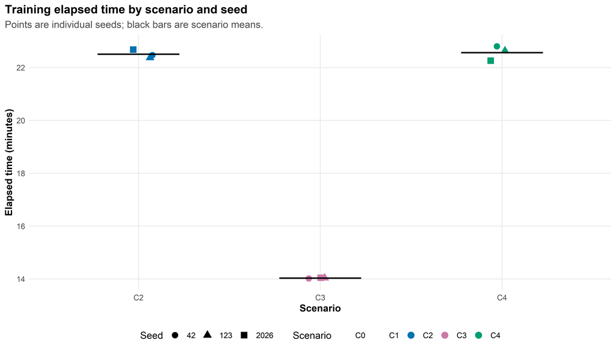

```r
p_elapsed_seed <- training_runs |>
  ggplot(aes(x = scenario_short, y = elapsed_minutes, color = scenario_short)) +
  geom_point(aes(shape = factor(seed)), size = 3.4, position = position_jitter(width = 0.08, height = 0)) +
  stat_summary(
    fun = mean,
    geom = "crossbar",
    width = 0.45,
    color = "black",
    linewidth = 0.35
  ) +
  scale_color_manual(values = scenario_palette, drop = FALSE) +
  labs(
    title = "Training elapsed time by scenario and seed",
    subtitle = "Points are individual seeds; black bars are scenario means.",
    x = "Scenario",
    y = "Elapsed time (minutes)",
    color = "Scenario",
    shape = "Seed"
  ) +
  base_theme()

print(p_elapsed_seed)
```

```r
save_training_figure(
  p_elapsed_seed,
  "01_training_elapsed_time_by_seed.png",
  width = 10.5,
  height = 6
)
```

## 11.2 Mean training time by scenario

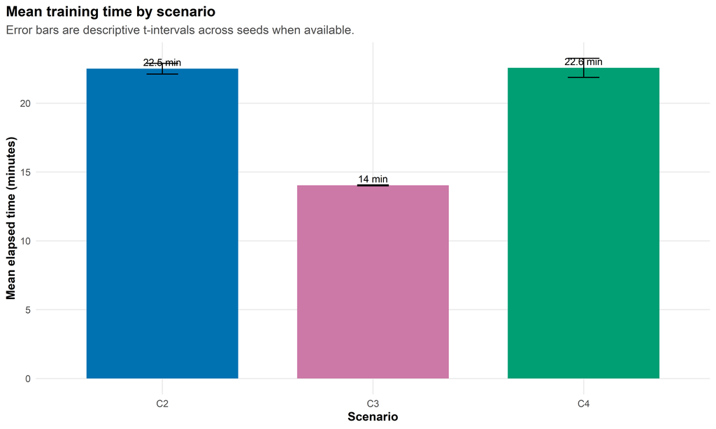

```r
p_elapsed_mean <- scenario_training_summary |>
  ggplot(aes(x = scenario_short, y = mean_elapsed_minutes, fill = scenario_short)) +
  geom_col(width = 0.72, show.legend = FALSE) +
  geom_errorbar(
    aes(ymin = ci95_low_elapsed_minutes, ymax = ci95_high_elapsed_minutes),
    width = 0.15,
    na.rm = TRUE
  ) +
  geom_text(
    aes(label = paste0(round(mean_elapsed_minutes, 1), " min")),
    vjust = -0.4,
    size = 3.5
  ) +
  scale_fill_manual(values = scenario_palette, drop = FALSE) +
  labs(
    title = "Mean training time by scenario",
    subtitle = "Error bars are descriptive t-intervals across seeds when available.",
    x = "Scenario",
    y = "Mean elapsed time (minutes)"
  ) +
  base_theme()

print(p_elapsed_mean)
```

```r
save_training_figure(
  p_elapsed_mean,
  "02_mean_training_elapsed_time.png",
  width = 10,
  height = 6
)
```

## 11.3 Runtime vs elapsed time

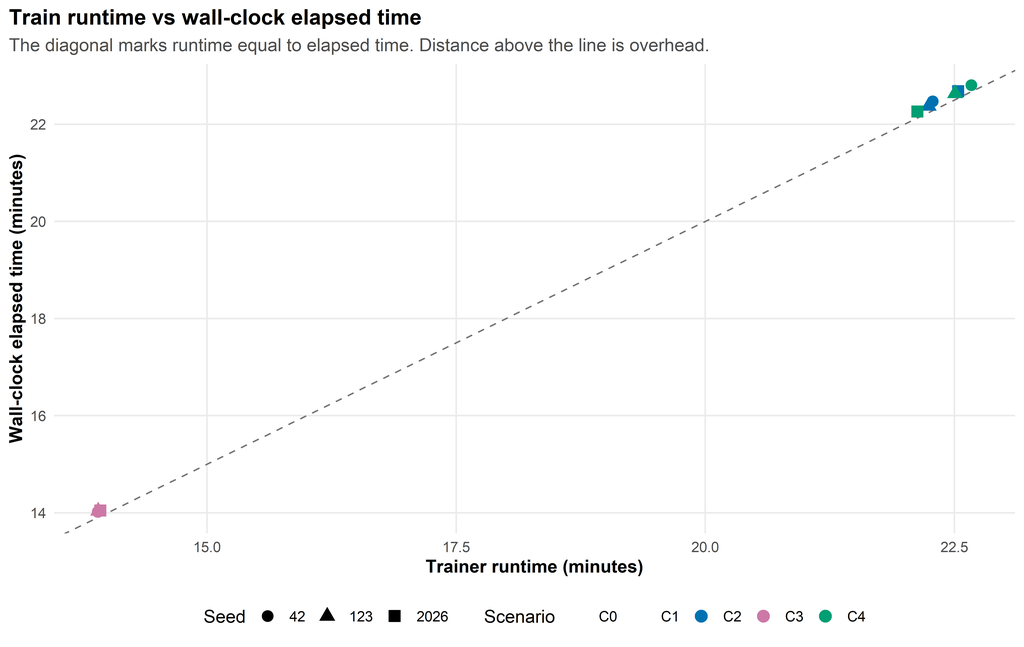

```r
p_runtime_elapsed <- training_runs |>
  ggplot(aes(x = train_runtime_minutes, y = elapsed_minutes, color = scenario_short)) +
  geom_abline(slope = 1, intercept = 0, linetype = "dashed", color = "grey45") +
  geom_point(aes(shape = factor(seed)), size = 3.4) +
  scale_color_manual(values = scenario_palette, drop = FALSE) +
  labs(
    title = "Train runtime vs wall-clock elapsed time",
    subtitle = "The diagonal marks runtime equal to elapsed time. Distance above the line is overhead.",
    x = "Trainer runtime (minutes)",
    y = "Wall-clock elapsed time (minutes)",
    color = "Scenario",
    shape = "Seed"
  ) +
  base_theme()

print(p_runtime_elapsed)
```

```r
save_training_figure(
  p_runtime_elapsed,
  "03_train_runtime_vs_elapsed_time.png",
  width = 9.5,
  height = 6
)
```

## 11.4 Throughput by scenario

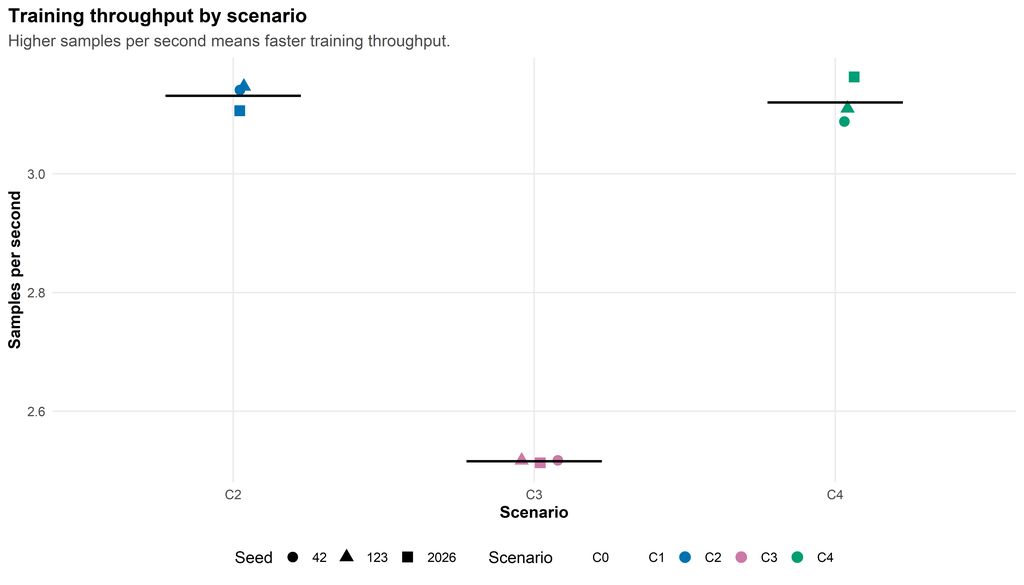

```r
p_throughput <- training_runs |>
  ggplot(aes(x = scenario_short, y = train_samples_per_second, color = scenario_short)) +
  geom_point(aes(shape = factor(seed)), size = 3.4, position = position_jitter(width = 0.08, height = 0)) +
  stat_summary(
    fun = mean,
    geom = "crossbar",
    width = 0.45,
    color = "black",
    linewidth = 0.35
  ) +
  scale_color_manual(values = scenario_palette, drop = FALSE) +
  labs(
    title = "Training throughput by scenario",
    subtitle = "Higher samples per second means faster training throughput.",
    x = "Scenario",
    y = "Samples per second",
    color = "Scenario",
    shape = "Seed"
  ) +
  base_theme()

print(p_throughput)
```

```r
save_training_figure(
  p_throughput,
  "04_training_throughput_samples_per_second.png",
  width = 10.5,
  height = 6
)
```

## 11.5 Steps per second

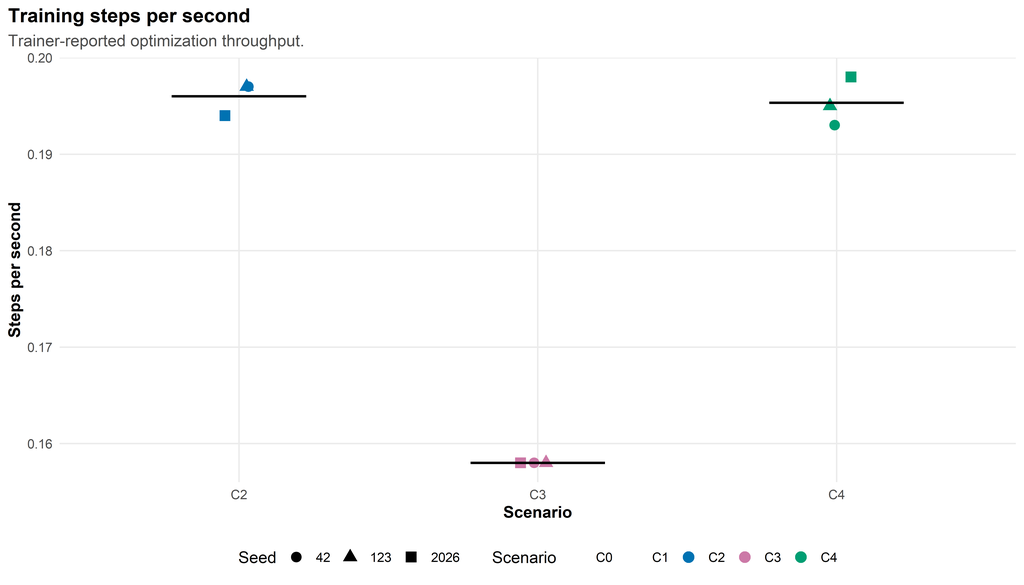

```r
p_steps <- training_runs |>
  ggplot(aes(x = scenario_short, y = train_steps_per_second, color = scenario_short)) +
  geom_point(aes(shape = factor(seed)), size = 3.4, position = position_jitter(width = 0.08, height = 0)) +
  stat_summary(
    fun = mean,
    geom = "crossbar",
    width = 0.45,
    color = "black",
    linewidth = 0.35
  ) +
  scale_color_manual(values = scenario_palette, drop = FALSE) +
  labs(
    title = "Training steps per second",
    subtitle = "Trainer-reported optimization throughput.",
    x = "Scenario",
    y = "Steps per second",
    color = "Scenario",
    shape = "Seed"
  ) +
  base_theme()

print(p_steps)
```

```r
save_training_figure(
  p_steps,
  "05_training_steps_per_second.png",
  width = 10.5,
  height = 6
)
```

## 11.6 Train loss by scenario

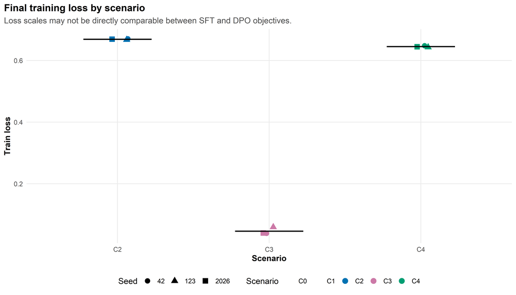

```r
p_loss <- training_runs |>
  ggplot(aes(x = scenario_short, y = train_loss, color = scenario_short)) +
  geom_point(aes(shape = factor(seed)), size = 3.4, position = position_jitter(width = 0.08, height = 0)) +
  stat_summary(
    fun = mean,
    geom = "crossbar",
    width = 0.45,
    color = "black",
    linewidth = 0.35
  ) +
  scale_color_manual(values = scenario_palette, drop = FALSE) +
  labs(
    title = "Final training loss by scenario",
    subtitle = "Loss scales may not be directly comparable between SFT and DPO objectives.",
    x = "Scenario",
    y = "Train loss",
    color = "Scenario",
    shape = "Seed"
  ) +
  base_theme()

print(p_loss)
```

```r
save_training_figure(
  p_loss,
  "06_train_loss_by_scenario.png",
  width = 10.5,
  height = 6
)
```

## 11.7 Total FLOPs by scenario

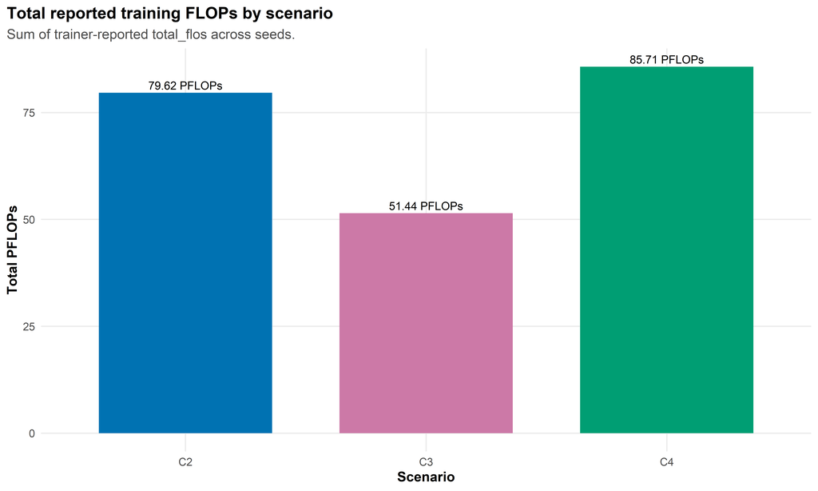

```r
p_flops <- scenario_training_summary |>
  ggplot(aes(x = scenario_short, y = total_pflops, fill = scenario_short)) +
  geom_col(width = 0.72, show.legend = FALSE) +
  geom_text(
    aes(label = paste0(round(total_pflops, 2), " PFLOPs")),
    vjust = -0.4,
    size = 3.5
  ) +
  scale_fill_manual(values = scenario_palette, drop = FALSE) +
  labs(
    title = "Total reported training FLOPs by scenario",
    subtitle = "Sum of trainer-reported total_flos across seeds.",
    x = "Scenario",
    y = "Total PFLOPs"
  ) +
  base_theme()

print(p_flops)
```

```r
save_training_figure(
  p_flops,
  "07_total_training_flops_by_scenario.png",
  width = 10,
  height = 6
)
```

## 11.8 Training timeline

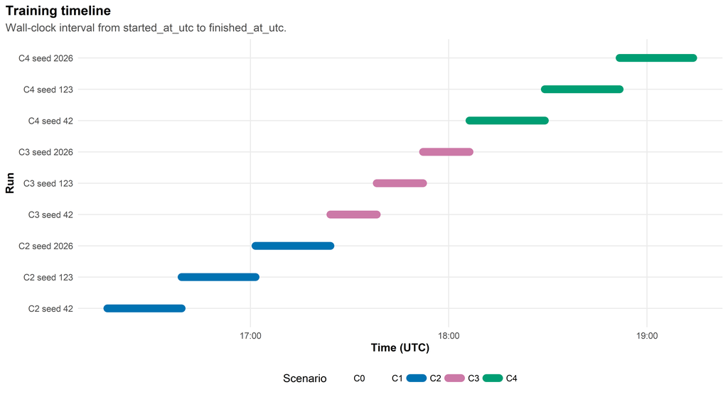

```r
timeline_data <- training_runs |>
  mutate(
    run_label = paste0(scenario_short, " seed ", seed),
    run_label = fct_reorder(run_label, as.numeric(started_at))
  )

p_timeline <- timeline_data |>
  ggplot(aes(y = run_label, color = scenario_short)) +
  geom_segment(
    aes(x = started_at, xend = finished_at, yend = run_label),
    linewidth = 4,
    lineend = "round"
  ) +
  scale_color_manual(values = scenario_palette, drop = FALSE) +
  labs(
    title = "Training timeline",
    subtitle = "Wall-clock interval from started_at_utc to finished_at_utc.",
    x = "Time (UTC)",
    y = "Run",
    color = "Scenario"
  ) +
  base_theme()

print(p_timeline)
```

```r
save_training_figure(
  p_timeline,
  "08_training_timeline.png",
  width = 11,
  height = 6
)
```

## 11.9 Event timeline

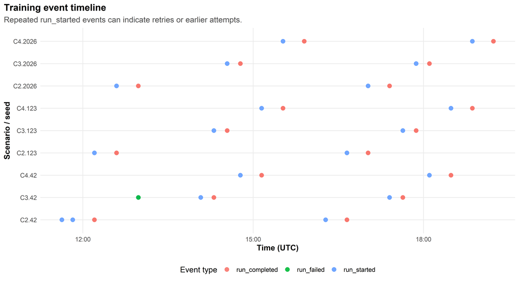

```r
if (exists("training_events") && nrow(training_events) > 0) {
  p_event_timeline <- training_events |>
    ggplot(aes(x = timestamp, y = interaction(scenario_short, seed), color = event_type)) +
    geom_point(size = 2.7, alpha = 0.9) +
    labs(
      title = "Training event timeline",
      subtitle = "Repeated run_started events can indicate retries or earlier attempts.",
      x = "Time (UTC)",
      y = "Scenario / seed",
      color = "Event type"
    ) +
    base_theme()

  print(p_event_timeline)

  save_training_figure(
    p_event_timeline,
    "09_training_event_timeline.png",
    width = 11,
    height = 6
  )
}
```

## 11.10 Relative cost comparison

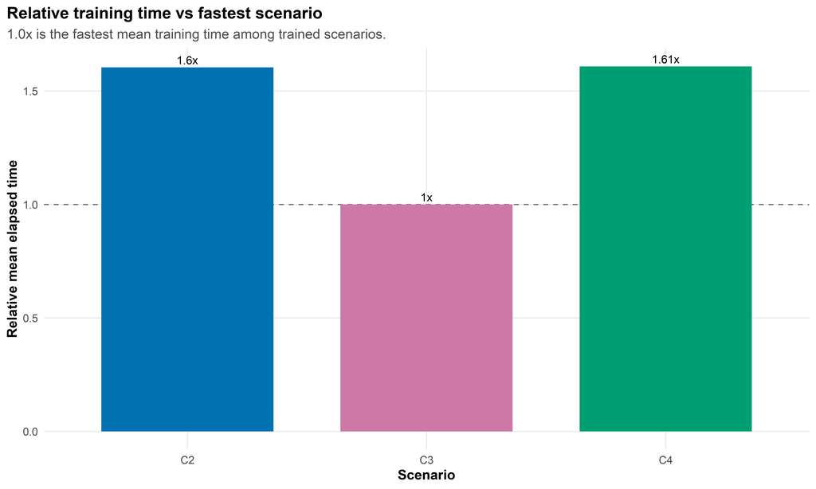

```r
p_relative_cost <- training_cost_comparison |>
  ggplot(aes(x = scenario_short, y = relative_time_vs_fastest, fill = scenario_short)) +
  geom_hline(yintercept = 1, linetype = "dashed", color = "grey45") +
  geom_col(width = 0.72, show.legend = FALSE) +
  geom_text(
    aes(label = paste0(round(relative_time_vs_fastest, 2), "x")),
    vjust = -0.4,
    size = 3.5
  ) +
  scale_fill_manual(values = scenario_palette, drop = FALSE) +
  labs(
    title = "Relative training time vs fastest scenario",
    subtitle = "1.0x is the fastest mean training time among trained scenarios.",
    x = "Scenario",
    y = "Relative mean elapsed time"
  ) +
  base_theme()

print(p_relative_cost)
```

```r
save_training_figure(
  p_relative_cost,
  "10_relative_training_time_vs_fastest.png",
  width = 10,
  height = 6
)
```

# 12 Paper-ready training time table

```r
paper_training_time_table <- scenario_training_summary |>
  select(
    scenario_short,
    method_label,
    n_runs,
    n_completed,
    seeds,
    train_rows,
    validation_rows,
    total_elapsed_hours,
    mean_elapsed_minutes,
    sd_elapsed_seconds,
    mean_train_runtime_minutes,
    mean_samples_per_second,
    mean_steps_per_second,
    mean_overhead_rate,
    total_pflops,
    mean_train_loss
  ) |>
  mutate(
    total_elapsed_hours = fmt_number(total_elapsed_hours),
    mean_elapsed_minutes = fmt_number(mean_elapsed_minutes),
    sd_elapsed_minutes = fmt_number(sd_elapsed_seconds / 60),
    mean_train_runtime_minutes = fmt_number(mean_train_runtime_minutes),
    mean_samples_per_second = fmt_number(mean_samples_per_second, accuracy = 0.001),
    mean_steps_per_second = fmt_number(mean_steps_per_second, accuracy = 0.001),
    mean_overhead_rate = scales::percent(mean_overhead_rate, accuracy = 0.1),
    total_pflops = fmt_number(total_pflops, accuracy = 0.001),
    mean_train_loss = fmt_number(mean_train_loss, accuracy = 0.0001)
  ) |>
  select(-sd_elapsed_seconds)

write_training_csv(paper_training_time_table, "12_paper_ready_training_time_table.csv")

paper_training_time_table |>
  knitr::kable(
    caption = "Table 10 - Paper-ready training time table."
  )
```

Table 10 - Paper-ready training time table.

| scenario_short | method_label | n_runs | n_completed | seeds | train_rows | validation_rows | total_elapsed_hours | mean_elapsed_minutes | mean_train_runtime_minutes | mean_samples_per_second | mean_steps_per_second | mean_overhead_rate | total_pflops | mean_train_loss | sd_elapsed_minutes |
| --- | --- | --- | --- | --- | --- | --- | --- | --- | --- | --- | --- | --- | --- | --- | --- |
| C2 | SFT | 3 | 3 | 42, 123, 2026 | 4200 | 700 | 1.13 | 22.51 | 22.36 | 3.131 | 0.196 | 0.7% | 79.619 | 0.6690 | 0.16 |
| C3 | DPO | 3 | 3 | 42, 123, 2026 | 2100 | 350 | 0.70 | 14.03 | 13.91 | 2.516 | 0.158 | 0.9% | 51.436 | 0.0460 | 0.01 |
| C4 | SFT | 3 | 3 | 42, 123, 2026 | 4200 | 700 | 1.13 | 22.57 | 22.44 | 3.120 | 0.195 | 0.6% | 85.707 | 0.6453 | 0.28 |

# 13 Interpretation notes

```r
cat("
## How to interpret this report

This analysis summarizes wall-clock training time and trainer-reported runtime metrics for the trained scenarios C2, C3, and C4.

Elapsed time is the end-to-end wall-clock time between started_at_utc and finished_at_utc. Train runtime is the runtime reported by the trainer. The difference between elapsed time and train runtime is reported as overhead.

SFT and DPO train losses should not be directly compared as if they were the same objective. Loss is useful within a method, but method-level comparisons should focus more on runtime, throughput, and final downstream metrics from the evaluation Rmds.

C0 and C1 are not included as training runs because C0 is the base model and C1 is a format-only prompt strategy.
")
```

## 13.1 How to interpret this report

This analysis summarizes wall-clock training time and trainer-reported runtime metrics for the trained scenarios C2, C3, and C4.

Elapsed time is the end-to-end wall-clock time between started_at_utc and finished_at_utc. Train runtime is the runtime reported by the trainer. The difference between elapsed time and train runtime is reported as overhead.

SFT and DPO train losses should not be directly compared as if they were the same objective. Loss is useful within a method, but method-level comparisons should focus more on runtime, throughput, and final downstream metrics from the evaluation Rmds.

C0 and C1 are not included as training runs because C0 is the base model and C1 is a format-only prompt strategy.

# 14 Generated files

Tables are saved in:

```
tables/training_time_analysis/
```

Figures are saved in:

```
figures/training_time_analysis/
```

Main files:

```
01_experiment_training_metadata.csv
02_training_runs_enriched.csv
03_run_metadata_files_enriched.csv
04_scenario_training_time_summary.csv
05_method_training_time_summary.csv
06_training_events_enriched.csv
07_training_event_counts.csv
08_training_retry_summary.csv
09_training_completion_events.csv
10_training_error_files.csv
11_training_cost_comparison.csv
12_paper_ready_training_time_table.csv

01_training_elapsed_time_by_seed.png
02_mean_training_elapsed_time.png
03_train_runtime_vs_elapsed_time.png
04_training_throughput_samples_per_second.png
05_training_steps_per_second.png
06_train_loss_by_scenario.png
07_total_training_flops_by_scenario.png
08_training_timeline.png
09_training_event_timeline.png
10_relative_training_time_vs_fastest.png
```